# Predicción del rating de Las aplicaciones en Google Play Store

Reto DataSource

[Edimer (Sidereus)](https://edimer.github.io/)

- [Sitio oficial del reto en DataSource.](https://www.datasource.ai/es/home/data-science-competitions-for-startups/prediciendo-el-rating-de-las-aplicaciones-en-google-play-store)

# Variables

# Datos

```r
# Cargando datos
library(tidyverse)
load("../data/my_train1.Rdata")
load("../data/my_test1.Rdata")
sampleSub <- read_csv("../data/sample_submission.csv")
head(new_train1)
```

- Selecciono sólo las variables que van a ingresar al análisis.

```r
mi_train <- new_train1 %>%
  select(-c(App, date_update))

mi_test <- new_test1 %>%
  select(-c(App, date_update))
```

- Primero se garantiza que los modelos sean entrenados con las mismas variables que contiene el archivo de test (submission).

```r
library(fastDummies)
# Binarización en test
binar_train <- dummy_cols(mi_train, remove_selected_columns = TRUE)
binar_test <- dummy_cols(mi_test, remove_selected_columns = TRUE)

# Las mismas variables en train y test (submission)
variables_iguales <- c(names(binar_train)[names(binar_train) %in% names(binar_test)],
                       "Rating")

# Datos de train finales
binar_train <- binar_train[, variables_iguales]
```

# Modelos Árbol de Decisión

- [Ejemplo árboles de decisión con R](https://blogrpy.netlify.app/posts/treed_r/)
- El mismo preprocesamiento que utilicé para el entrenamiento de Support Vector Machine.
  - **Receta:** binarización (previamente binarizadas), datos con imputación por knn, [transformación de Yeo–Johnson](https://en.wikipedia.org/wiki/Power_transform#Yeo%E2%80%93Johnson_transformation) y como es un problema de clasificación imbalanceado, utilizo la biblioteca themis para generar clases balanceadas a través de muestreo con reemplazo.
- En este caso voy a entrenar [árboles de decisión](https://parsnip.tidymodels.org/reference/decision_tree.html) con tres algoritmos diferentes:
  - [Algoritmo rpart](https://cran.r-project.org/web/packages/rpart/vignettes/longintro.pdf)
  - [Algoritmo C5.0](https://topepo.github.io/C5.0/index.html)
  - [Random Forest](https://parsnip.tidymodels.org/reference/rand_forest.html)
- Pasos a seguir con *tidymodels*:
  - 1. Definir preprocesamiento
  - 2. Definir el modelo y los hiperparámetros a optimizar
  - 3. Definir la estrategia de validación del modelo
  - 4. Definir tipo de *tuning* (grid de hiperparámetros)
  - 5. Ejecución o entrenamiento de modelos
  - 6. Evaluación de modelos (gráficos con métricas de error)
  - 7. Ajuste del modelo final
  - 8. Predicciones finales

# Preprocesamiento

## Receta principal

```r
# Preprocesamiento
library(themis)
library(tidymodels)

# Train-Test
set.seed(2020)
data_split <- initial_split(data = binar_train, prop = 0.80)
data_train <- training(data_split) %>% mutate(Rating = as.factor(Rating))
data_test <- testing(data_split) %>% mutate(Rating = as.factor(Rating))

# Receta
receta1 <- recipe(Rating ~ ., data = data_train) %>%
  step_knnimpute(all_predictors(), neighbors = 2) %>%
  step_YeoJohnson(all_numeric(), -all_outcomes()) %>%
  step_upsample(Rating)

receta1_prep <- receta1 %>%
  prep()
```

## Receta Submission

```r
receta_sub <- recipe(~ ., data = mi_test) %>%
  step_knnimpute(all_predictors(), neighbors = 2) %>%
  step_YeoJohnson(all_numeric(), -all_outcomes())

prep_sub <- prep(receta_sub)
data_sub <- juice(prep_sub)
```

# Algoritmo `rpart`

## Entrenamiento

- **Tiempo de ejecución:** aproximadamente 20 minutos.

```r
# Tiempo de ejecución
library(tictoc)
tic()

# Definición de modelo e ingeniería
modelo_rpart <- decision_tree(
  mode = "classification",
  cost_complexity = tune(),
  tree_depth = tune(),
  min_n = tune()

) %>%
  set_engine("rpart")

# Definición de validación del modelo
set.seed(1234)
cv_config <- vfold_cv(data = data_train,
                      v = 10,
                      strata = Rating)

# Flujo de trabajo
flujo_rpart <- workflow() %>%
  add_recipe(receta1) %>%
  add_model(modelo_rpart)

# Hiperparámetros
hiper_rpart <- grid_random(cost_complexity(range = c(-5, 5), trans = log10_trans()),
                           tree_depth(range = c(1L, 30L)),
                           min_n(range = c(2L, 20L)),
                           size = 100)

# Entrenamiento paralelizado
doParallel::registerDoParallel()
fit_rpart <- tune_grid(object = flujo_rpart,
                           resamples = cv_config,
                           metrics = metric_set(f_meas),
                           control = control_resamples(save_pred = TRUE),
                           grid = hiper_rpart)
doParallel::stopImplicitCluster()
toc()
```

## Resultados Train

```r
fit_rpart %>%
  collect_metrics() %>%
  arrange(desc(mean))
```

- **Hiperparámetros individuales:**

```r
fit_rpart %>%
  collect_metrics() %>%
  select(cost_complexity:min_n, mean, std_err) %>%
  pivot_longer(cols = !c(mean, std_err), names_to = "variable",
               values_to = "value") %>%
  ggplot(aes(x = value, y = mean)) +
  facet_wrap(~variable, scales = "free") +
  geom_point() +
  geom_smooth(se = FALSE, size = 1, color = "red")
```

- **Todos los hiperparámetros:**

```r
fit_rpart %>%
  collect_metrics() %>%
  ggplot(aes(x = cost_complexity, y = tree_depth, size = min_n, color = mean)) +
  geom_point() +
  scale_color_viridis_c() +
  labs(color = "F1 Score") +
  scale_x_log10() +
  scale_y_log10()
```

## Modelo Final

```r
mejor_tuning <- select_best(fit_rpart)

modelo_final <- finalize_workflow(flujo_rpart,
                                  parameters = mejor_tuning)

doParallel::registerDoParallel()
ajuste_final <- modelo_final %>%
  fit(data_train)
doParallel::stopImplicitCluster()
```

## Predicciones

### Train

- **Train:**

```r
predichos_train <- ajuste_final$fit$fit %>%
  predict(new_data = juice(receta1_prep) %>% select(-Rating), type = "class") %>%
  bind_cols(juice(receta1_prep) %>%  select(Rating)) %>%
  mutate_all(as.factor)
head(predichos_train)
```

- **Matriz de confusión train:**

```r
predichos_train %>%
  conf_mat(Rating, .pred_class) %>%
  pluck(1) %>%
  as_tibble() %>%
  ggplot(aes(x = Prediction, y = Truth, alpha = n)) +
  geom_tile(show.legend = FALSE) +
  geom_text(aes(label = n), colour = "white", alpha = 1, size = 8)
```

- **Precisión en train:**

```r
predichos_train %>%
  metrics(Rating, .pred_class) %>%
  select(-.estimator) %>%
  filter(.metric == "accuracy")
```

- **F1 Score train:**

```r
predichos_train %>%
  f_meas(Rating, .pred_class) %>%
  select(-.estimator)
```

### Validación

- **Validación:**

```r
# Receta en Test
test_baked  <- bake(object = receta1_prep, new_data = data_test)

predichos_test <- ajuste_final$fit$fit %>%
  predict(new_data = test_baked %>% select(-Rating), type = "class") %>%
  bind_cols(test_baked %>% select(Rating)) %>%
  mutate_all(as.factor)
head(predichos_test)
```

- **Matriz de confusión test:**

```r
predichos_test %>%
  conf_mat(Rating, .pred_class) %>%
  pluck(1) %>%
  as_tibble() %>%
  ggplot(aes(x = Prediction, y = Truth, alpha = n)) +
  geom_tile(show.legend = FALSE) +
  geom_text(aes(label = n), colour = "white", alpha = 1, size = 8)
```

- **Precisión en validación:**

```r
predichos_test %>%
  metrics(Rating, .pred_class) %>%
  select(-.estimator) %>%
  filter(.metric == "accuracy")
```

- **F1 Score validación:**

```r
predichos_test %>%
  f_meas(Rating, .pred_class) %>%
  select(-.estimator)
```

### Submission

- **Modelo con todos los datos:**

```r
new_train <- bake(object = receta1_prep, new_data = binar_train)
ultimo_ajuste <- modelo_final %>%
  fit(new_train)
```

- **Predicciones finales:**

```r
#predicciones
binar_sub <- dummy_cols(data_sub, remove_selected_columns = TRUE)

predichos_final1 <- ultimo_ajuste$fit$fit %>%
  predict(new_data = binar_sub, type = "class")

# Submission
sampleSub %>%
  select(-rating) %>%
  mutate(rating = predichos_final1$.pred_class) ->
  sub_04_rpart
head(sub_04_rpart)
```

- **Exportando predicciones:**

```r
write_csv(sub_04_rpart, file = "../submission/sub_04_rpart.csv")
```

# Algoritmo `C5.0`

## Entrenamiento

- **Tiempo de ejecución:** aproximadamente 5 minutos.

```r
# Tiempo de ejecución
library(tictoc)
tic()

# Definición de modelo e ingeniería
modelo_c5 <- decision_tree(
  mode = "classification",
  min_n = tune()

) %>%
  set_engine("C5.0")

# Definición de validación del modelo
set.seed(1234)
cv_config <- vfold_cv(data = data_train,
                      v = 10,
                      strata = Rating)

# Flujo de trabajo
flujo_c5 <- workflow() %>%
  add_recipe(receta1) %>%
  add_model(modelo_c5)

# Hiperparámetros
hiper_c5 <- grid_random(min_n(range = c(2L, 20L)),
                        size = 100)

# Entrenamiento paralelizado
doParallel::registerDoParallel()
fit_c5 <- tune_grid(object = flujo_c5,
                           resamples = cv_config,
                           metrics = metric_set(f_meas),
                           control = control_resamples(save_pred = TRUE),
                           grid = hiper_c5)
doParallel::stopImplicitCluster()
toc()
```

## Resultados Train

```r
fit_c5 %>%
  collect_metrics() %>%
  arrange(desc(mean))
```

- **Hiperparámetros individuales:**

```r
fit_c5 %>%
  collect_metrics() %>%
  select(min_n, mean, std_err) %>%
  pivot_longer(cols = !c(mean, std_err), names_to = "variable",
               values_to = "value") %>%
  ggplot(aes(x = value, y = mean)) +
  facet_wrap(~variable, scales = "free") +
  geom_point() +
  geom_smooth(se = FALSE, size = 1, color = "red")
```

## Modelo Final

```r
mejor_tuning <- select_best(fit_c5)

modelo_final <- finalize_workflow(flujo_c5,
                                  parameters = mejor_tuning)

doParallel::registerDoParallel()
ajuste_final <- modelo_final %>%
  fit(data_train)
doParallel::stopImplicitCluster()
```

## Predicciones

### Train

- **Train:**

```r
predichos_train <- ajuste_final$fit$fit %>%
  predict(new_data = juice(receta1_prep) %>% select(-Rating), type = "class") %>%
  bind_cols(juice(receta1_prep) %>%  select(Rating)) %>%
  mutate_all(as.factor)
head(predichos_train)
```

- **Matriz de confusión train:**

```r
predichos_train %>%
  conf_mat(Rating, .pred_class) %>%
  pluck(1) %>%
  as_tibble() %>%
  ggplot(aes(x = Prediction, y = Truth, alpha = n)) +
  geom_tile(show.legend = FALSE) +
  geom_text(aes(label = n), colour = "white", alpha = 1, size = 8)
```

- **Precisión en train:**

```r
predichos_train %>%
  metrics(Rating, .pred_class) %>%
  select(-.estimator) %>%
  filter(.metric == "accuracy")
```

- **F1 Score train:**

```r
predichos_train %>%
  f_meas(Rating, .pred_class) %>%
  select(-.estimator)
```

### Validación

- **Validación:**

```r
# Receta en Test
test_baked  <- bake(object = receta1_prep, new_data = data_test)

predichos_test <- ajuste_final$fit$fit %>%
  predict(new_data = test_baked %>% select(-Rating), type = "class") %>%
  bind_cols(test_baked %>% select(Rating)) %>%
  mutate_all(as.factor)
head(predichos_test)
```

- **Matriz de confusión test:**

```r
predichos_test %>%
  conf_mat(Rating, .pred_class) %>%
  pluck(1) %>%
  as_tibble() %>%
  ggplot(aes(x = Prediction, y = Truth, alpha = n)) +
  geom_tile(show.legend = FALSE) +
  geom_text(aes(label = n), colour = "white", alpha = 1, size = 8)
```

- **Precisión en validación:**

```r
predichos_test %>%
  metrics(Rating, .pred_class) %>%
  select(-.estimator) %>%
  filter(.metric == "accuracy")
```

- **F1 Score validación:**

```r
predichos_test %>%
  f_meas(Rating, .pred_class) %>%
  select(-.estimator)
```

### Submission

- **Modelo con todos los datos:**

```r
new_train <- bake(object = receta1_prep, new_data = binar_train)
ultimo_ajuste <- modelo_final %>%
  fit(new_train)
```

- **Predicciones finales:**

```r
#predicciones
binar_sub <- dummy_cols(data_sub, remove_selected_columns = TRUE)

predichos_final1 <- ultimo_ajuste$fit$fit %>%
  predict(new_data = binar_sub, type = "class")

# Submission
sampleSub %>%
  select(-rating) %>%
  mutate(rating = predichos_final1$.pred_class) ->
  sub_05_c5
head(sub_05_c5)
```

- **Exportando predicciones:**

```r
write_csv(sub_05_c5, file = "../submission/sub_05_c5.csv")
```

# Random Forest

## Entrenamiento

- **Tiempo de ejecución:** aproximadamente 20 horas.

```r
# Tiempo de ejecución
library(tictoc)
tic()

# Definición de modelo e ingeniería
modelo_rf <- rand_forest(
  mode = "classification",
  mtry = tune(),
  trees = tune(),
  min_n = tune()
) %>%
  set_engine("ranger")

# Definición de validación del modelo
set.seed(1234)
cv_config <- vfold_cv(data = data_train,
                      v = 10,
                      strata = Rating)

# Flujo de trabajo
flujo_rf <- workflow() %>%
  add_recipe(receta1) %>%
  add_model(modelo_rf)

# Hiperparámetros
hiper_rf <-
  grid_random(
    mtry(range = c(1L, ncol(data_train))),
    trees(range = c(1L, 5000L)),
    min_n(range = c(2L, 50L)),
    size = 100
  )

# Entrenamiento paralelizado
doParallel::registerDoParallel()
fit_rf <- tune_grid(
  object = flujo_rf,
  resamples = cv_config,
  metrics = metric_set(f_meas),
  control = control_resamples(save_pred = TRUE),
  grid = hiper_rf
)
doParallel::stopImplicitCluster()
toc()
```

```
68745.86 sec elapsed
```

## Resultados Train

```r
fit_rf %>%
  collect_metrics() %>%
  arrange(desc(mean))
```

| mtry | trees | min_n | .metric | .estimator | mean | n | std_err | .config |
| --- | --- | --- | --- | --- | --- | --- | --- | --- |
| 76 | 2533 | 49 | f_meas | binary | 0.4934810 | 10 | 0.010426236 | Model082 |
| 24 | 4285 | 48 | f_meas | binary | 0.4927900 | 10 | 0.011242886 | Model083 |
| 15 | 3676 | 42 | f_meas | binary | 0.4922905 | 10 | 0.011434210 | Model036 |
| 59 | 4535 | 50 | f_meas | binary | 0.4909070 | 10 | 0.010124006 | Model058 |
| 95 | 193 | 50 | f_meas | binary | 0.4903480 | 10 | 0.010691367 | Model084 |
| 90 | 3080 | 48 | f_meas | binary | 0.4898747 | 10 | 0.009231853 | Model054 |
| 42 | 1602 | 45 | f_meas | binary | 0.4897708 | 10 | 0.009658483 | Model040 |
| 72 | 3094 | 49 | f_meas | binary | 0.4893332 | 10 | 0.009730585 | Model077 |
| 82 | 4719 | 50 | f_meas | binary | 0.4893089 | 10 | 0.010222447 | Model091 |
| 37 | 676 | 50 | f_meas | binary | 0.4891463 | 10 | 0.011168266 | Model005 |

[output cut: 90 more lines]

- **Hiperparámetros individuales:**

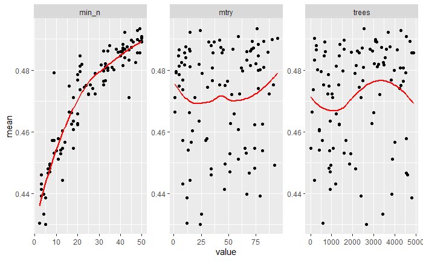

```r
fit_rf %>%
  collect_metrics() %>%
  select(mtry:min_n, mean, std_err) %>%
  pivot_longer(cols = !c(mean, std_err), names_to = "variable",
               values_to = "value") %>%
  ggplot(aes(x = value, y = mean)) +
  facet_wrap(~variable, scales = "free") +
  geom_point() +
  geom_smooth(se = FALSE, size = 1, color = "red")
```

- **Todos los hiperparámetros:**

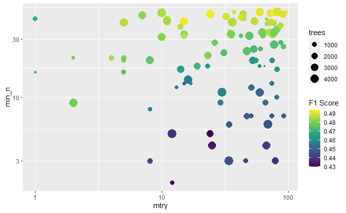

```r
fit_rf %>%
  collect_metrics() %>%
  ggplot(aes(x = mtry, y = min_n, size = trees, color = mean)) +
  geom_point() +
  scale_color_viridis_c() +
  labs(color = "F1 Score") +
  scale_x_log10() +
  scale_y_log10()
```

## Modelo Final

```r
mejor_tuning <- select_best(fit_rf)

modelo_final <- finalize_workflow(flujo_rf,
                                  parameters = mejor_tuning)

doParallel::registerDoParallel()
ajuste_final <- modelo_final %>%
  fit(data_train)
doParallel::stopImplicitCluster()
```

## Predicciones

### Train

- **Train:**

```r
predichos_train <- ajuste_final$fit$fit %>%
  predict(new_data = juice(receta1_prep) %>% select(-Rating), type = "class") %>%
  bind_cols(juice(receta1_prep) %>%  select(Rating)) %>%
  mutate_all(as.factor)
head(predichos_train)
```

| .pred_class | Rating |
| --- | --- |
| 0 | 0 |
| 0 | 0 |
| 0 | 0 |
| 0 | 0 |
| 0 | 0 |
| 0 | 0 |

- **Matriz de confusión train:**

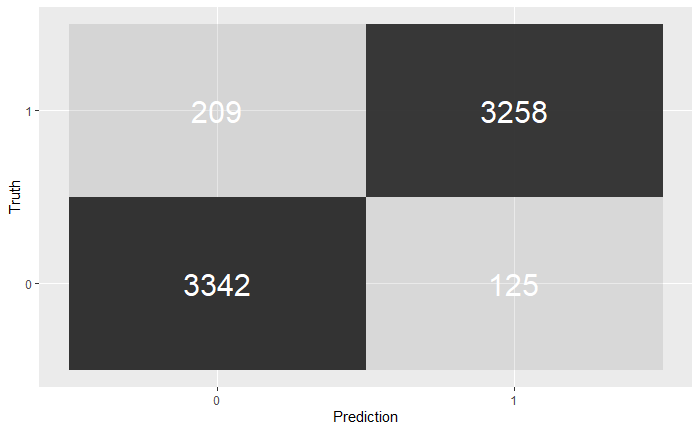

```r
predichos_train %>%
  conf_mat(Rating, .pred_class) %>%
  pluck(1) %>%
  as_tibble() %>%
  ggplot(aes(x = Prediction, y = Truth, alpha = n)) +
  geom_tile(show.legend = FALSE) +
  geom_text(aes(label = n), colour = "white", alpha = 1, size = 8)
```

- **Precisión en train:**

```r
predichos_train %>%
  metrics(Rating, .pred_class) %>%
  select(-.estimator) %>%
  filter(.metric == "accuracy")
```

| .metric | .estimate |
| --- | --- |
| accuracy | 0.9518316 |

- **F1 Score train:**

```r
predichos_train %>%
  f_meas(Rating, .pred_class) %>%
  select(-.estimator)
```

| .metric | .estimate |
| --- | --- |
| f_meas | 0.9524081 |

### Validación

- **Validación:**

```r
# Receta en Test
test_baked  <- bake(object = receta1_prep, new_data = data_test)

predichos_test <- ajuste_final$fit$fit %>%
  predict(new_data = test_baked %>% select(-Rating), type = "class") %>%
  bind_cols(test_baked %>% select(Rating)) %>%
  mutate_all(as.factor)
head(predichos_test)
```

| .pred_class | Rating |
| --- | --- |
| 0 | 1 |
| 0 | 1 |
| 1 | 1 |
| 1 | 1 |
| 0 | 1 |
| 1 | 1 |

- **Matriz de confusión test:**

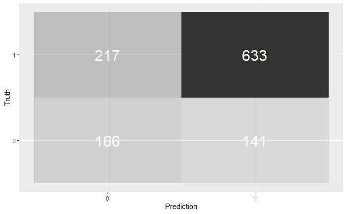

```r
predichos_test %>%
  conf_mat(Rating, .pred_class) %>%
  pluck(1) %>%
  as_tibble() %>%
  ggplot(aes(x = Prediction, y = Truth, alpha = n)) +
  geom_tile(show.legend = FALSE) +
  geom_text(aes(label = n), colour = "white", alpha = 1, size = 8)
```

- **Precisión en validación:**

```r
predichos_test %>%
  metrics(Rating, .pred_class) %>%
  select(-.estimator) %>%
  filter(.metric == "accuracy")
```

| .metric | .estimate |
| --- | --- |
| accuracy | 0.6905791 |

- **F1 Score validación:**

```r
predichos_test %>%
  f_meas(Rating, .pred_class) %>%
  select(-.estimator)
```

| .metric | .estimate |
| --- | --- |
| f_meas | 0.4811594 |

### Submission

- **Modelo con todos los datos:**

```r
new_train <- bake(object = receta1_prep, new_data = binar_train)
ultimo_ajuste <- modelo_final %>%
  fit(new_train)
```

- **Predicciones finales:**

```r
#predicciones
binar_sub <- dummy_cols(data_sub, remove_selected_columns = TRUE)

predichos_final1 <- ultimo_ajuste$fit$fit %>%
  predict(new_data = binar_sub, type = "class")

# Submission
sampleSub %>%
  select(-rating) %>%
  mutate(rating = predichos_final1$.pred_class) ->
  sub_06_rf
head(sub_06_rf)
```

| id | rating |
| --- | --- |
| 5788 | 1 |
| 5789 | 1 |
| 5790 | 1 |
| 5791 | 1 |
| 5792 | 1 |
| 5793 | 1 |

- **Exportando predicciones:**

```r
write_csv(sub_06_rf, file = "../submission/sub_06_rf.csv")
```